# churn_analysis

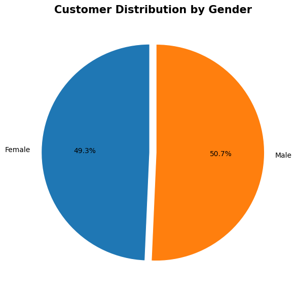

```python
plt.figure(figsize=(6,6))

plt.pie(
    gender_dist["customers"],
    labels=gender_dist["gender"],
    autopct="%1.1f%%",
    startangle=90,
    explode=[0.03]*len(gender_dist),
    wedgeprops={"edgecolor":"white"}
)

plt.title(
    "Customer Distribution by Gender",
    fontsize=15,
    fontweight="bold"
)

plt.tight_layout()
plt.show()
```

```python
customer_state = (
    df.groupby("state")
      .agg(
          Customers=("customerid","count")
      )
      .sort_values("Customers",ascending=False)
      .reset_index()
)

customer_state.head(10)
```

<style scoped> .dataframe tbody tr th:only-of-type { vertical-align: middle; } .dataframe tbody tr th { vertical-align: top; } .dataframe thead th { text-align: right; } </style> <thead> <th></th> <th>state</th> <th>Customers</th> </thead> <tbody> <th>0</th> <th>1</th> <th>2</th> <th>3</th> <th>4</th> <th>5</th> <th>6</th> <th>7</th> <th>8</th> <th>9</th> </tbody>

| Assam | 68 |
| --- | --- |
| Bihar | 67 |
| Haryana | 67 |
| Madhya Pradesh | 60 |
| Gujarat | 60 |
| West Bengal | 58 |
| Jharkhand | 58 |
| Maharashtra | 57 |
| Kerala | 55 |
| Odisha | 53 |

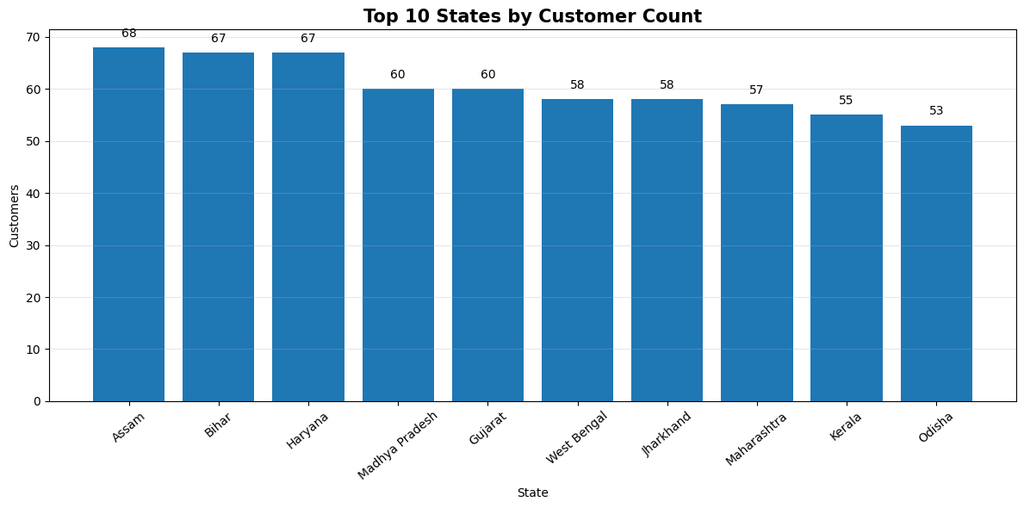

```python
plt.figure(figsize=(12,6))

bars = plt.bar(
    customer_state["state"][:10],
    customer_state["Customers"][:10]
)

plt.title(
    "Top 10 States by Customer Count",
    fontsize=15,
    fontweight="bold"
)

plt.xlabel("State")
plt.ylabel("Customers")

plt.xticks(rotation=40)

for bar in bars:
    plt.text(
        bar.get_x()+bar.get_width()/2,
        bar.get_height()+2,
        int(bar.get_height()),
        ha="center",
        fontsize=10
    )

plt.grid(axis="y",alpha=.3)

plt.tight_layout()
plt.show()
```

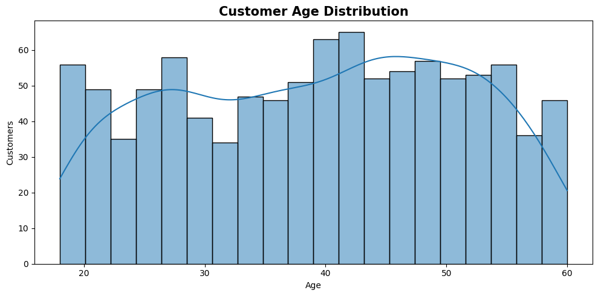

```python
plt.figure(figsize=(10,5))

sns.histplot(
    data=df,
    x="customer_age",
    bins=20,
    kde=True
)

plt.title(
    "Customer Age Distribution",
    fontsize=15,
    fontweight="bold"
)

plt.xlabel("Age")

plt.ylabel("Customers")

plt.tight_layout()

plt.show()
```

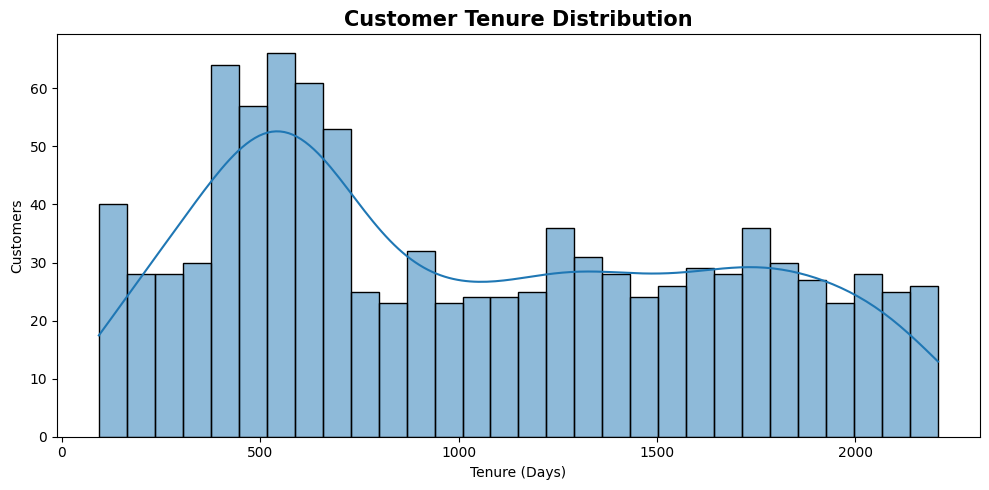

```python
plt.figure(figsize=(10,5))

sns.histplot(
    data=df,
    x="tenure_days",
    bins=30,
    kde=True
)

plt.title(
    "Customer Tenure Distribution",
    fontsize=15,
    fontweight="bold"
)

plt.xlabel("Tenure (Days)")
plt.ylabel("Customers")

plt.tight_layout()

plt.show()
```

```python
# ===========================================
# CONTRACT TYPE DISTRIBUTION
# ===========================================

contract_dist = (
    df.groupby("contract_type")
      .agg(Customers=("customerid","count"))
      .reset_index()
)

display(contract_dist)
```

<style scoped> .dataframe tbody tr th:only-of-type { vertical-align: middle; } .dataframe tbody tr th { vertical-align: top; } .dataframe thead th { text-align: right; } </style> <thead> <th></th> <th>contract_type</th> <th>Customers</th> </thead> <tbody> <th>0</th> <th>1</th> </tbody>

| Annual | 492 |
| --- | --- |
| Monthly | 508 |

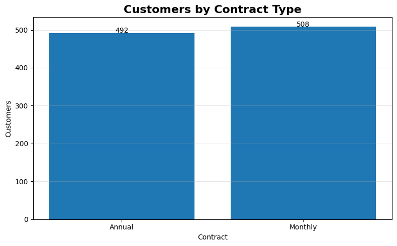

```python
plt.figure(figsize=(8,5))

bars = plt.bar(
    contract_dist["contract_type"],
    contract_dist["Customers"]
)

plt.title(
    "Customers by Contract Type",
    fontsize=16,
    fontweight="bold"
)

plt.xlabel("Contract")

plt.ylabel("Customers")

for bar in bars:
    plt.text(
        bar.get_x()+bar.get_width()/2,
        bar.get_height()+1,
        int(bar.get_height()),
        ha='center'
    )

plt.grid(axis='y',alpha=.3)

plt.tight_layout()

plt.show()
```

```python
# ===========================================
# MONTHLY CHARGES DISTRIBUTION
# ===========================================

print(df["monthly_charges"].describe())
```

```
count    1000.000000
mean       15.662000
std         6.978619
min         6.990000
25%         9.740000
50%        13.990000
75%        19.990000
max        29.990000
Name: monthly_charges, dtype: float64
```

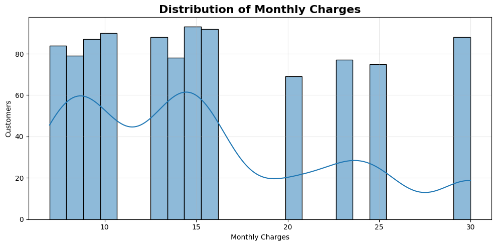

```python
plt.figure(figsize=(10,5))

sns.histplot(
    data=df,
    x="monthly_charges",
    bins=25,
    kde=True
)

plt.title(
    "Distribution of Monthly Charges",
    fontsize=16,
    fontweight="bold"
)

plt.xlabel("Monthly Charges")

plt.ylabel("Customers")

plt.grid(alpha=.3)

plt.tight_layout()

plt.show()
```

```python
# ============================================
# REVENUE ANALYTICS
# ============================================
```

```python
total_revenue = df["monthly_charges"].sum()

print(f"Total Monthly Revenue : ₹{total_revenue:,.2f}")
```

```
Total Monthly Revenue : ₹15,662.00
```

```python
revenue_plan = (
    df.groupby("plan_type")
      .agg(
          Customers=("customerid","count"),
          Revenue=("monthly_charges","sum"),
          Average_Revenue=("monthly_charges","mean"),
          Avg_CLTV=("cltv","mean")
      )
      .sort_values("Revenue",ascending=False)
      .reset_index()
)

revenue_plan["Revenue %"] = (
    revenue_plan["Revenue"] /
    revenue_plan["Revenue"].sum()*100
).round(2)

display(revenue_plan)
```

<style scoped> .dataframe tbody tr th:only-of-type { vertical-align: middle; } .dataframe tbody tr th { vertical-align: top; } .dataframe thead th { text-align: right; } </style> <thead> <th></th> <th>plan_type</th> <th>Customers</th> <th>Revenue</th> <th>Average_Revenue</th> <th>Avg_CLTV</th> <th>Revenue %</th> </thead> <tbody> <th>0</th> <th>1</th> <th>2</th> </tbody>

| Premium | 322 | 7327.78 | 22.757081 | 2621.605590 | 46.79 |
| --- | --- | --- | --- | --- | --- |
| Standard | 351 | 4953.49 | 14.112507 | 1196.390313 | 31.63 |
| Basic | 327 | 3380.73 | 10.338624 | 711.171254 | 21.59 |

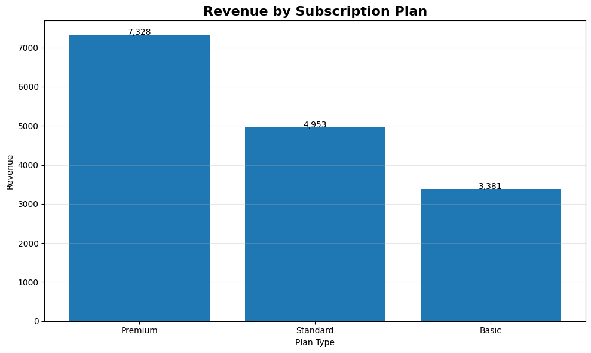

```python
plt.figure(figsize=(10,6))

bars = plt.bar(
    revenue_plan["plan_type"],
    revenue_plan["Revenue"]
)

plt.title(
    "Revenue by Subscription Plan",
    fontsize=16,
    fontweight="bold"
)

plt.xlabel("Plan Type")
plt.ylabel("Revenue")

for bar in bars:
    plt.text(
        bar.get_x()+bar.get_width()/2,
        bar.get_height(),
        f"{bar.get_height():,.0f}",
        ha='center',
        fontsize=10
    )

plt.grid(axis='y',alpha=.3)

plt.tight_layout()

plt.show()
```

```python
revenue_state = (
    df.groupby("state")
      .agg(
          Customers=("customerid","count"),
          Revenue=("monthly_charges","sum"),
          AvgRevenue=("monthly_charges","mean")
      )
      .sort_values("Revenue",ascending=False)
      .reset_index()
)

display(revenue_state.head(10))
```

<style scoped> .dataframe tbody tr th:only-of-type { vertical-align: middle; } .dataframe tbody tr th { vertical-align: top; } .dataframe thead th { text-align: right; } </style> <thead> <th></th> <th>state</th> <th>Customers</th> <th>Revenue</th> <th>AvgRevenue</th> </thead> <tbody> <th>0</th> <th>1</th> <th>2</th> <th>3</th> <th>4</th> <th>5</th> <th>6</th> <th>7</th> <th>8</th> <th>9</th> </tbody>

| Assam | 68 | 1149.32 | 16.901765 |
| --- | --- | --- | --- |
| Haryana | 67 | 990.33 | 14.781045 |
| Bihar | 67 | 989.33 | 14.766119 |
| Kerala | 55 | 978.45 | 17.790000 |
| Maharashtra | 57 | 960.43 | 16.849649 |
| Madhya Pradesh | 60 | 940.40 | 15.673333 |
| Jharkhand | 58 | 870.42 | 15.007241 |
| Gujarat | 60 | 857.40 | 14.290000 |
| West Bengal | 58 | 851.42 | 14.679655 |
| Rajasthan | 49 | 831.51 | 16.969592 |

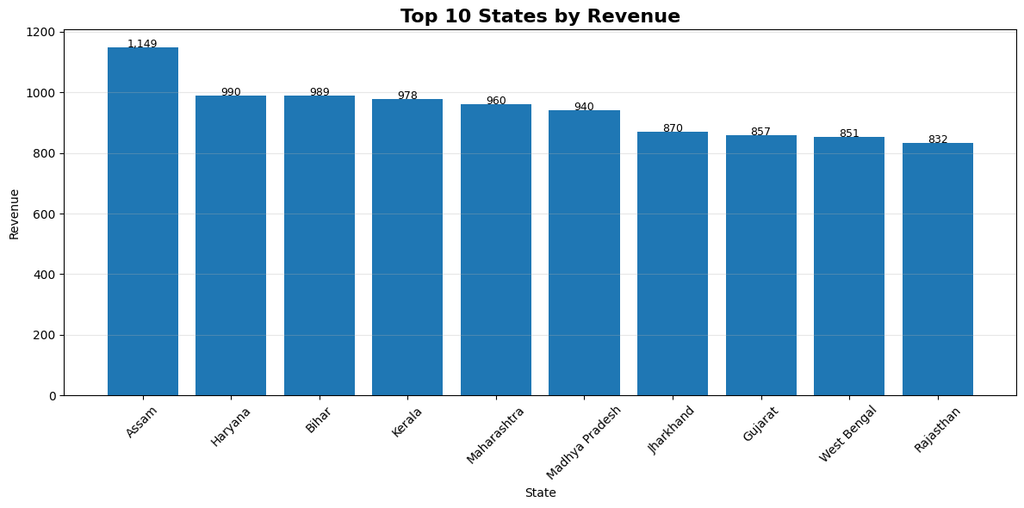

```python
plt.figure(figsize=(12,6))

bars = plt.bar(
    revenue_state["state"][:10],
    revenue_state["Revenue"][:10]
)

plt.title(
    "Top 10 States by Revenue",
    fontsize=16,
    fontweight="bold"
)

plt.xticks(rotation=45)

plt.xlabel("State")
plt.ylabel("Revenue")

for bar in bars:
    plt.text(
        bar.get_x()+bar.get_width()/2,
        bar.get_height(),
        f"{bar.get_height():,.0f}",
        ha="center",
        fontsize=9
    )

plt.grid(axis='y',alpha=.3)

plt.tight_layout()

plt.show()
```

```python
contract_revenue = (
    df.groupby("contract_type")
      .agg(
          Customers=("customerid","count"),
          Revenue=("monthly_charges","sum"),
          AvgRevenue=("monthly_charges","mean"),
          AvgCLTV=("cltv","mean")
      )
      .sort_values("Revenue",ascending=False)
      .reset_index()
)

display(contract_revenue)
```

<style scoped> .dataframe tbody tr th:only-of-type { vertical-align: middle; } .dataframe tbody tr th { vertical-align: top; } .dataframe thead th { text-align: right; } </style> <thead> <th></th> <th>contract_type</th> <th>Customers</th> <th>Revenue</th> <th>AvgRevenue</th> <th>AvgCLTV</th> </thead> <tbody> <th>0</th> <th>1</th> </tbody>

| Annual | 492 | 9290.08 | 18.882276 | 1996.199187 |
| --- | --- | --- | --- | --- |
| Monthly | 508 | 6371.92 | 12.543150 | 1012.820866 |

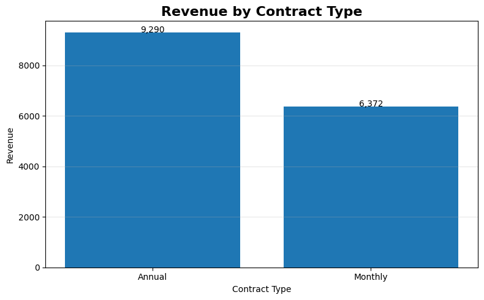

```python
plt.figure(figsize=(8,5))

bars = plt.bar(
    contract_revenue["contract_type"],
    contract_revenue["Revenue"]
)

plt.title(
    "Revenue by Contract Type",
    fontsize=16,
    fontweight="bold"
)

plt.xlabel("Contract Type")
plt.ylabel("Revenue")

for bar in bars:
    plt.text(
        bar.get_x()+bar.get_width()/2,
        bar.get_height(),
        f"{bar.get_height():,.0f}",
        ha='center'
    )

plt.grid(axis='y',alpha=.3)

plt.tight_layout()

plt.show()
```

```python
revenue_lost = (
    df[df["churn_flag"]==1]
    .groupby("plan_type")
    .agg(
        Lost_Customers=("customerid","count"),
        Revenue_Lost=("monthly_charges","sum")
    )
    .sort_values("Revenue_Lost",ascending=False)
    .reset_index()
)

display(revenue_lost)
```

<style scoped> .dataframe tbody tr th:only-of-type { vertical-align: middle; } .dataframe tbody tr th { vertical-align: top; } .dataframe thead th { text-align: right; } </style> <thead> <th></th> <th>plan_type</th> <th>Lost_Customers</th> <th>Revenue_Lost</th> </thead> <tbody> <th>0</th> <th>1</th> <th>2</th> </tbody>

| Basic | 178 | 2104.22 |
| --- | --- | --- |
| Standard | 65 | 812.35 |
| Premium | 54 | 667.46 |

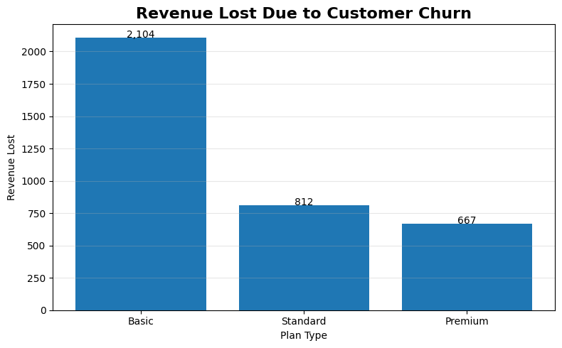

```python
plt.figure(figsize=(8,5))

bars = plt.bar(
    revenue_lost["plan_type"],
    revenue_lost["Revenue_Lost"]
)

plt.title(
    "Revenue Lost Due to Customer Churn",
    fontsize=16,
    fontweight="bold"
)

plt.xlabel("Plan Type")
plt.ylabel("Revenue Lost")

for bar in bars:
    plt.text(
        bar.get_x()+bar.get_width()/2,
        bar.get_height(),
        f"{bar.get_height():,.0f}",
        ha='center'
    )

plt.grid(axis='y',alpha=.3)

plt.tight_layout()

plt.show()
```

```python
top_customers = (
    df[
        [
            "customerid",
            "customer_name",
            "plan_type",
            "monthly_charges",
            "cltv",
            "state"
        ]
    ]
    .sort_values("cltv",ascending=False)
    .head(10)
)

display(top_customers)
```

<style scoped> .dataframe tbody tr th:only-of-type { vertical-align: middle; } .dataframe tbody tr th { vertical-align: top; } .dataframe thead th { text-align: right; } </style> <thead> <th></th> <th>customerid</th> <th>customer_name</th> <th>plan_type</th> <th>monthly_charges</th> <th>cltv</th> <th>state</th> </thead> <tbody> <th>368</th> <th>367</th> <th>674</th> <th>282</th> <th>67</th> <th>344</th> <th>798</th> <th>195</th> <th>665</th> <th>555</th> </tbody>

| 0369-YRAJB | Aarav | Premium | 22.99 | 3997 | Haryana |
| --- | --- | --- | --- | --- | --- |
| 0368-YLKGZ | Brijesh | Premium | 19.99 | 3997 | Jharkhand |
| 0675-LXFBP | Ansh | Premium | 29.99 | 3996 | Delhi |
| 0283-QIOIZ | Dipta | Premium | 19.99 | 3993 | Delhi |
| 0068-TACAM | Abdul | Premium | 22.99 | 3987 | Nagaland |
| 0345-QZAOH | Ladli | Premium | 24.99 | 3980 | Uttar Pradesh |
| 0799-SFFIH | Finn | Premium | 24.99 | 3974 | Kerala |
| 0196-DZQGT | Udant | Premium | 19.99 | 3954 | Assam |
| 0666-SONMN | Isaac | Premium | 24.99 | 3945 | Madhya Pradesh |
| 0556-HOLHL | Jairaj | Premium | 29.99 | 3938 | Uttar Pradesh |

```python
pareto = (
    df.groupby("state")
      .agg(Revenue=("monthly_charges","sum"))
      .sort_values("Revenue",ascending=False)
)

pareto["CumRevenue"] = pareto["Revenue"].cumsum()

pareto["CumPercent"] = (
    pareto["CumRevenue"] /
    pareto["Revenue"].sum()*100
)
```

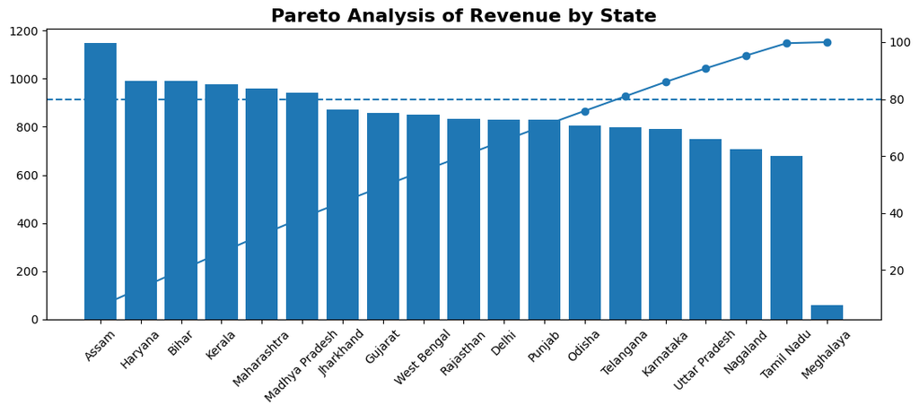

```python
fig, ax1 = plt.subplots(figsize=(11,5))

ax1.bar(
    pareto.index,
    pareto["Revenue"]
)

ax2 = ax1.twinx()

ax2.plot(
    pareto.index,
    pareto["CumPercent"],
    marker='o'
)

ax2.axhline(
    80,
    linestyle='--'
)

ax1.set_xticklabels(
    pareto.index,
    rotation=45
)

plt.title(
    "Pareto Analysis of Revenue by State",
    fontsize=16,
    fontweight="bold"
)

plt.tight_layout()

plt.show()
```

<h1 id="%F0%9F%93%8A-Revenue-Analytics-%E2%80%93-Executive-Summary">📊 Revenue Analytics – Executive Summary</h1><hr /> <h2 id="%F0%9F%8E%AF-Business-Objective">🎯 Business Objective</h2><p>Evaluate how revenue is distributed across customer segments, subscription plans, contract types, and geographic regions to identify high-value customers, major revenue contributors, and potential revenue leakage due to customer churn.</p> <hr /> <h2 id="%F0%9F%94%8D-Key-Insights">🔍 Key Insights</h2><h3 id="%F0%9F%92%B0-Revenue-Contribution-by-Plan">💰 Revenue Contribution by Plan</h3>

- Premium plans generated the highest share of total monthly revenue despite serving a comparatively smaller customer base.
- Higher average monthly charges and CLTV indicate that premium subscribers contribute significantly more revenue per customer.

<hr /> <h3 id="%F0%9F%8C%8D-Geographic-Revenue-Distribution">🌍 Geographic Revenue Distribution</h3>

- Revenue is concentrated in a limited number of states, with the top-performing regions contributing a substantial share of overall revenue.
- These regions represent strategic markets for customer retention and targeted marketing initiatives.

<hr /> <h3 id="%F0%9F%93%89-Revenue-Loss-Due-to-Churn">📉 Revenue Loss Due to Churn</h3>

- Customers on Monthly contracts accounted for a disproportionately high share of revenue lost through churn.
- This suggests that shorter contract commitments are associated with higher customer attrition and increased revenue leakage.

<hr /> <h3 id="%F0%9F%91%91-High-Value-Customers">👑 High-Value Customers</h3>

- The top 10 customers exhibited significantly higher Customer Lifetime Value (CLTV) compared to the overall customer base.
- Protecting these high-value customers through personalized engagement and loyalty initiatives can maximize long-term profitability.

<hr /> <h3 id="%F0%9F%93%88-Revenue-Concentration-(Pareto-Analysis)">📈 Revenue Concentration (Pareto Analysis)</h3>

- Revenue follows the Pareto Principle, where a relatively small percentage of states contribute the majority of total revenue.
- Prioritizing customer acquisition and retention efforts in these high-performing regions can deliver the greatest business impact.

<hr /> <h2 id="%F0%9F%92%BC-Business-Recommendations">💼 Business Recommendations</h2>

- Increase adoption of Premium subscription plans through personalized upgrade campaigns.
- Strengthen retention programs for Monthly contract customers to reduce revenue leakage.
- Launch region-specific marketing campaigns targeting high-revenue states.
- Develop VIP retention strategies for customers with the highest CLTV.
- Allocate marketing and customer success resources based on revenue contribution rather than customer volume alone.

<hr /> <h2 id="%F0%9F%93%8C-Conclusion">📌 Conclusion</h2><p>The revenue analysis reveals that customer value is unevenly distributed across plans, contracts, and geographic regions. Focusing retention efforts on high-value customers and high-revenue markets, while reducing churn among Monthly contract users, presents the greatest opportunity to improve long-term revenue and customer lifetime value.</p>

```python
# ============================================
# CUSTOMER SEGMENTATION
# ============================================

def customer_segment(row):

    # Champions
    if row["cltv"] >= df["cltv"].quantile(0.75) and row["churn_risk"] == "Low":
        return "Champion"

    # High Value
    elif row["cltv"] >= df["cltv"].quantile(0.75):
        return "High Value"

    # Loyal
    elif row["tenure_days"] >= df["tenure_days"].quantile(0.75):
        return "Loyal"

    # At Risk
    elif row["churn_risk"] == "High":
        return "At Risk"

    # New Customers
    elif row["tenure_days"] <= df["tenure_days"].quantile(0.25):
        return "New Customer"

    else:
        return "Regular"


df["customer_segment"] = df.apply(customer_segment, axis=1)

display(df[["customerid","customer_segment"]].head())
```

<style scoped> .dataframe tbody tr th:only-of-type { vertical-align: middle; } .dataframe tbody tr th { vertical-align: top; } .dataframe thead th { text-align: right; } </style> <thead> <th></th> <th>customerid</th> <th>customer_segment</th> </thead> <tbody> <th>0</th> <th>1</th> <th>2</th> <th>3</th> <th>4</th> </tbody>

| 0002-ORFBO | Regular |
| --- | --- |
| 0003-MKNFE | Regular |
| 0004-TLHLJ | High Value |
| 0011-IGKFF | Regular |
| 0013-EXCHZ | Regular |

```python
segment_summary = (
    df.groupby("customer_segment")
      .agg(
          Customers=("customerid","count"),
          Avg_CLTV=("cltv","mean"),
          Avg_Monthly_Charges=("monthly_charges","mean"),
          Avg_Tenure=("tenure_days","mean"),
          Churn_Rate=("churn_flag","mean")
      )
      .reset_index()
)

segment_summary["Churn_Rate"] *= 100

segment_summary = segment_summary.sort_values(
    "Customers",
    ascending=False
)

display(segment_summary)
```

<style scoped> .dataframe tbody tr th:only-of-type { vertical-align: middle; } .dataframe tbody tr th { vertical-align: top; } .dataframe thead th { text-align: right; } </style> <thead> <th></th> <th>customer_segment</th> <th>Customers</th> <th>Avg_CLTV</th> <th>Avg_Monthly_Charges</th> <th>Avg_Tenure</th> <th>Churn_Rate</th> </thead> <tbody> <th>3</th> <th>0</th> <th>2</th> <th>1</th> </tbody>

| Regular | 357 | 1003.112045 | 13.110448 | 932.375350 | 22.128852 |
| --- | --- | --- | --- | --- | --- |
| High Value | 250 | 3152.912000 | 24.854000 | 1199.432000 | 12.400000 |
| New Customer | 215 | 734.567442 | 10.915581 | 327.037209 | 86.976744 |
| Loyal | 178 | 1080.741573 | 13.602360 | 1890.505618 | 0.000000 |

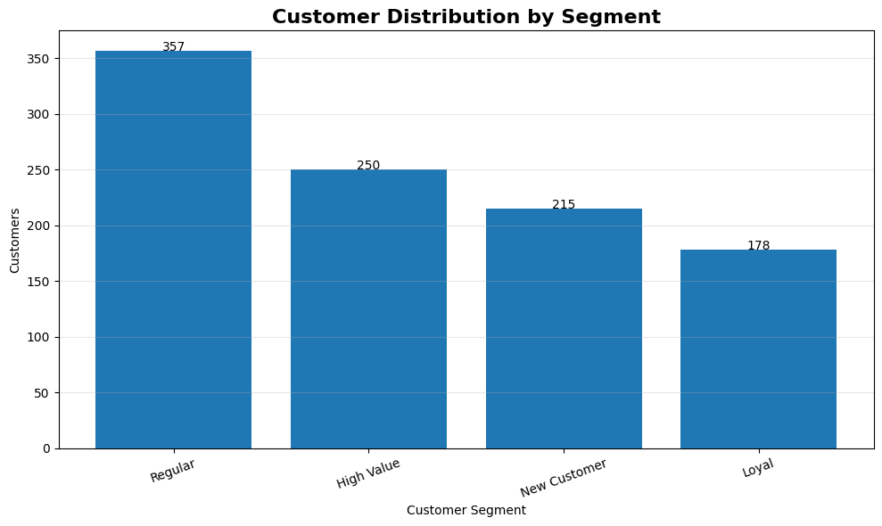

```python
plt.figure(figsize=(10,6))

bars = plt.bar(
    segment_summary["customer_segment"],
    segment_summary["Customers"]
)

plt.title(
    "Customer Distribution by Segment",
    fontsize=16,
    fontweight="bold"
)

plt.xlabel("Customer Segment")
plt.ylabel("Customers")

plt.xticks(rotation=20)

for bar in bars:
    plt.text(
        bar.get_x()+bar.get_width()/2,
        bar.get_height(),
        int(bar.get_height()),
        ha="center"
    )

plt.grid(axis="y",alpha=.3)

plt.tight_layout()

plt.show()
```

```python
segment_revenue = (
    df.groupby("customer_segment")
      .agg(
          Revenue=("monthly_charges","sum")
      )
      .sort_values("Revenue",ascending=False)
      .reset_index()
)

display(segment_revenue)
```

<style scoped> .dataframe tbody tr th:only-of-type { vertical-align: middle; } .dataframe tbody tr th { vertical-align: top; } .dataframe thead th { text-align: right; } </style> <thead> <th></th> <th>customer_segment</th> <th>Revenue</th> </thead> <tbody> <th>0</th> <th>1</th> <th>2</th> <th>3</th> </tbody>

| High Value | 6213.50 |
| --- | --- |
| Regular | 4680.43 |
| Loyal | 2421.22 |
| New Customer | 2346.85 |

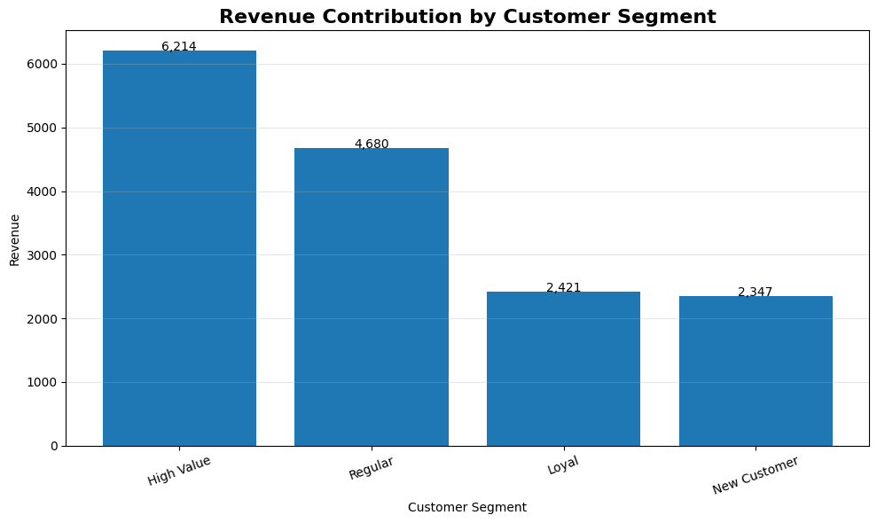

```python
plt.figure(figsize=(10,6))

bars = plt.bar(
    segment_revenue["customer_segment"],
    segment_revenue["Revenue"]
)

plt.title(
    "Revenue Contribution by Customer Segment",
    fontsize=16,
    fontweight="bold"
)

plt.xlabel("Customer Segment")
plt.ylabel("Revenue")

plt.xticks(rotation=20)

for bar in bars:
    plt.text(
        bar.get_x()+bar.get_width()/2,
        bar.get_height(),
        f"{bar.get_height():,.0f}",
        ha='center'
    )

plt.grid(axis='y',alpha=.3)

plt.tight_layout()

plt.show()
```

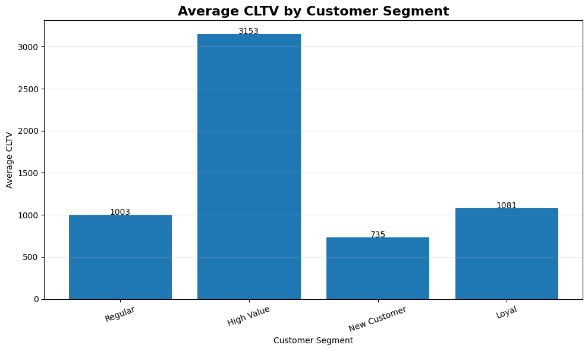

```python
plt.figure(figsize=(10,6))

bars = plt.bar(
    segment_summary["customer_segment"],
    segment_summary["Avg_CLTV"]
)

plt.title(
    "Average CLTV by Customer Segment",
    fontsize=16,
    fontweight="bold"
)

plt.xlabel("Customer Segment")
plt.ylabel("Average CLTV")

plt.xticks(rotation=20)

for bar in bars:
    plt.text(
        bar.get_x()+bar.get_width()/2,
        bar.get_height(),
        f"{bar.get_height():.0f}",
        ha='center'
    )

plt.grid(axis='y',alpha=.3)

plt.tight_layout()

plt.show()
```

```python
segment_churn = (
    df.groupby("customer_segment")
      .agg(
          Churn_Rate=("churn_flag","mean")
      )
      .reset_index()
)

segment_churn["Churn_Rate"] *= 100

display(segment_churn)
```

<style scoped> .dataframe tbody tr th:only-of-type { vertical-align: middle; } .dataframe tbody tr th { vertical-align: top; } .dataframe thead th { text-align: right; } </style> <thead> <th></th> <th>customer_segment</th> <th>Churn_Rate</th> </thead> <tbody> <th>0</th> <th>1</th> <th>2</th> <th>3</th> </tbody>

| High Value | 12.400000 |
| --- | --- |
| Loyal | 0.000000 |
| New Customer | 86.976744 |
| Regular | 22.128852 |

<h1 id="%F0%9F%8E%AF-Customer-Segmentation-%E2%80%93-Executive-Summary">🎯 Customer Segmentation – Executive Summary</h1><hr /> <h2 id="Business-Objective">Business Objective</h2><p>Identify distinct customer groups based on customer lifetime value (CLTV), tenure, and churn risk to support targeted retention, engagement, and revenue optimization strategies.</p> <hr /> <h2 id="Key-Insights">Key Insights</h2>

<hr /> <h2 id="Business-Recommendations">Business Recommendations</h2>

<hr /> <h2 id="Conclusion">Conclusion</h2><p>Customer segmentation enables the business to move from one-size-fits-all marketing to data-driven customer relationship management, maximizing customer lifetime value while reducing churn.</p>

```python
# ============================================
# CHURN RATE BY PLAN TYPE
# ============================================

plan_churn = (
    df.groupby("plan_type")
      .agg(
          Customers=("customerid","count"),
          Churned=("churn_flag","sum"),
          Churn_Rate=("churn_flag","mean")
      )
      .reset_index()
)

plan_churn["Churn_Rate"] = (
    plan_churn["Churn_Rate"]*100
).round(2)

display(plan_churn)
```

<style scoped> .dataframe tbody tr th:only-of-type { vertical-align: middle; } .dataframe tbody tr th { vertical-align: top; } .dataframe thead th { text-align: right; } </style> <thead> <th></th> <th>plan_type</th> <th>Customers</th> <th>Churned</th> <th>Churn_Rate</th> </thead> <tbody> <th>0</th> <th>1</th> <th>2</th> </tbody>

| Basic | 327 | 178 | 54.43 |
| --- | --- | --- | --- |
| Premium | 322 | 54 | 16.77 |
| Standard | 351 | 65 | 18.52 |

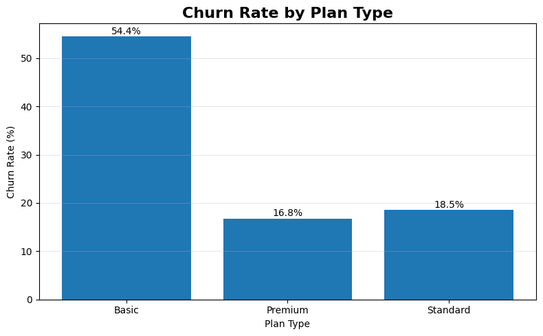

```python
plt.figure(figsize=(8,5))

bars = plt.bar(
    plan_churn["plan_type"],
    plan_churn["Churn_Rate"]
)

plt.title(
    "Churn Rate by Plan Type",
    fontsize=16,
    fontweight="bold"
)

plt.xlabel("Plan Type")
plt.ylabel("Churn Rate (%)")

for bar in bars:
    plt.text(
        bar.get_x()+bar.get_width()/2,
        bar.get_height()+0.5,
        f"{bar.get_height():.1f}%",
        ha='center'
    )

plt.grid(axis='y',alpha=.3)
plt.tight_layout()
plt.show()
```

```python
contract_churn = (
    df.groupby("contract_type")
      .agg(
          Customers=("customerid","count"),
          Churned=("churn_flag","sum"),
          Churn_Rate=("churn_flag","mean")
      )
      .reset_index()
)

contract_churn["Churn_Rate"] *=100

display(contract_churn)
```

<style scoped> .dataframe tbody tr th:only-of-type { vertical-align: middle; } .dataframe tbody tr th { vertical-align: top; } .dataframe thead th { text-align: right; } </style> <thead> <th></th> <th>contract_type</th> <th>Customers</th> <th>Churned</th> <th>Churn_Rate</th> </thead> <tbody> <th>0</th> <th>1</th> </tbody>

| Annual | 492 | 109 | 22.154472 |
| --- | --- | --- | --- |
| Monthly | 508 | 188 | 37.007874 |

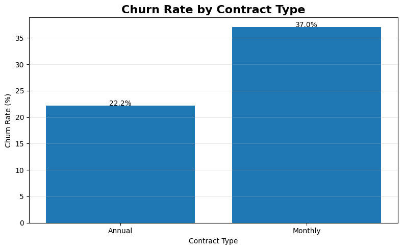

```python
plt.figure(figsize=(8,5))

bars = plt.bar(
    contract_churn["contract_type"],
    contract_churn["Churn_Rate"]
)

plt.title(
    "Churn Rate by Contract Type",
    fontsize=16,
    fontweight="bold"
)

plt.xlabel("Contract Type")
plt.ylabel("Churn Rate (%)")

for bar in bars:
    plt.text(
        bar.get_x()+bar.get_width()/2,
        bar.get_height(),
        f"{bar.get_height():.1f}%",
        ha='center'
    )

plt.grid(axis='y',alpha=.3)
plt.tight_layout()
plt.show()
```

```python
state_churn = (
    df.groupby("state")
      .agg(
          Customers=("customerid","count"),
          Churn_Rate=("churn_flag","mean")
      )
      .reset_index()
)

state_churn["Churn_Rate"]*=100

state_churn = state_churn.sort_values(
    "Churn_Rate",
    ascending=False
)

display(state_churn.head(10))
```

<style scoped> .dataframe tbody tr th:only-of-type { vertical-align: middle; } .dataframe tbody tr th { vertical-align: top; } .dataframe thead th { text-align: right; } </style> <thead> <th></th> <th>state</th> <th>Customers</th> <th>Churn_Rate</th> </thead> <tbody> <th>3</th> <th>15</th> <th>12</th> <th>1</th> <th>10</th> <th>9</th> <th>16</th> <th>18</th> <th>5</th> <th>14</th> </tbody>

| Gujarat | 60 | 41.666667 |
| --- | --- | --- |
| Tamil Nadu | 46 | 39.130435 |
| Odisha | 53 | 37.735849 |
| Bihar | 67 | 34.328358 |
| Meghalaya | 3 | 33.333333 |
| Maharashtra | 57 | 31.578947 |
| Telangana | 51 | 31.372549 |
| West Bengal | 58 | 29.310345 |
| Jharkhand | 58 | 29.310345 |
| Rajasthan | 49 | 28.571429 |

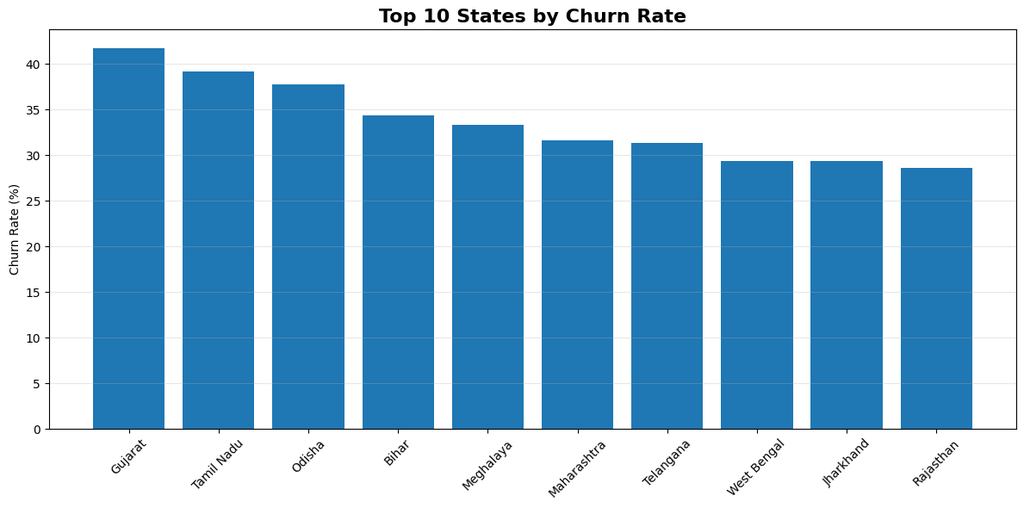

```python
plt.figure(figsize=(12,6))

bars = plt.bar(
    state_churn["state"][:10],
    state_churn["Churn_Rate"][:10]
)

plt.title(
    "Top 10 States by Churn Rate",
    fontsize=16,
    fontweight="bold"
)

plt.xticks(rotation=45)
plt.ylabel("Churn Rate (%)")

plt.grid(axis='y',alpha=.3)
plt.tight_layout()
plt.show()
```

```python
age_churn = (
    df.groupby("customer_age")
      .agg(
          Customers=("customerid","count"),
          Churn_Rate=("churn_flag","mean")
      )
      .reset_index()
)

age_churn["Churn_Rate"]*=100

display(age_churn)
```

<style scoped> .dataframe tbody tr th:only-of-type { vertical-align: middle; } .dataframe tbody tr th { vertical-align: top; } .dataframe thead th { text-align: right; } </style> <thead> <th></th> <th>customer_age</th> <th>Customers</th> <th>Churn_Rate</th> </thead> <tbody> <th>0</th> <th>1</th> <th>2</th> <th>3</th> <th>4</th> <th>5</th> <th>6</th> <th>7</th> <th>8</th> <th>9</th> <th>10</th> <th>11</th> <th>12</th> <th>13</th> <th>14</th> <th>15</th> <th>16</th> <th>17</th> <th>18</th> <th>19</th> <th>20</th> <th>21</th> <th>22</th> <th>23</th> <th>24</th> <th>25</th> <th>26</th> <th>27</th> <th>28</th> <th>29</th> <th>30</th> <th>31</th> <th>32</th> <th>33</th> <th>34</th> <th>35</th> <th>36</th> <th>37</th> <th>38</th> <th>39</th> <th>40</th> <th>41</th> <th>42</th> </tbody>

| 18 | 15 | 26.666667 |
| --- | --- | --- |
| 19 | 19 | 36.842105 |
| 20 | 22 | 22.727273 |
| 21 | 30 | 36.666667 |
| 22 | 19 | 26.315789 |
| 23 | 14 | 28.571429 |
| 24 | 21 | 9.523810 |
| 25 | 19 | 26.315789 |
| 26 | 30 | 43.333333 |
| 27 | 25 | 28.000000 |
| 28 | 33 | 39.393939 |
| 29 | 18 | 44.444444 |
| 30 | 23 | 13.043478 |
| 31 | 18 | 27.777778 |
| 32 | 16 | 31.250000 |
| 33 | 24 | 37.500000 |
| 34 | 23 | 17.391304 |
| 35 | 22 | 36.363636 |
| 36 | 24 | 33.333333 |
| 37 | 27 | 37.037037 |
| 38 | 24 | 37.500000 |
| 39 | 21 | 28.571429 |
| 40 | 24 | 29.166667 |
| 41 | 18 | 33.333333 |
| 42 | 25 | 36.000000 |
| 43 | 40 | 22.500000 |
| 44 | 23 | 26.086957 |
| 45 | 29 | 34.482759 |
| 46 | 33 | 21.212121 |
| 47 | 21 | 42.857143 |
| 48 | 32 | 25.000000 |
| 49 | 25 | 16.000000 |
| 50 | 25 | 36.000000 |
| 51 | 27 | 11.111111 |
| 52 | 31 | 29.032258 |
| 53 | 22 | 27.272727 |
| 54 | 36 | 16.666667 |
| 55 | 20 | 40.000000 |
| 56 | 11 | 54.545455 |
| 57 | 25 | 40.000000 |
| 58 | 15 | 33.333333 |
| 59 | 29 | 31.034483 |
| 60 | 2 | 0.000000 |

```python
complaint_churn = (
    df.groupby("complaint_count")
      .agg(
          Customers=("customerid","count"),
          Churn_Rate=("churn_flag","mean")
      )
      .reset_index()
)

complaint_churn["Churn_Rate"]*=100

display(complaint_churn)
```

<style scoped> .dataframe tbody tr th:only-of-type { vertical-align: middle; } .dataframe tbody tr th { vertical-align: top; } .dataframe thead th { text-align: right; } </style> <thead> <th></th> <th>complaint_count</th> <th>Customers</th> <th>Churn_Rate</th> </thead> <tbody> <th>0</th> <th>1</th> </tbody>

| 0 | 579 | 30.224525 |
| --- | --- | --- |
| 1 | 421 | 28.978622 |

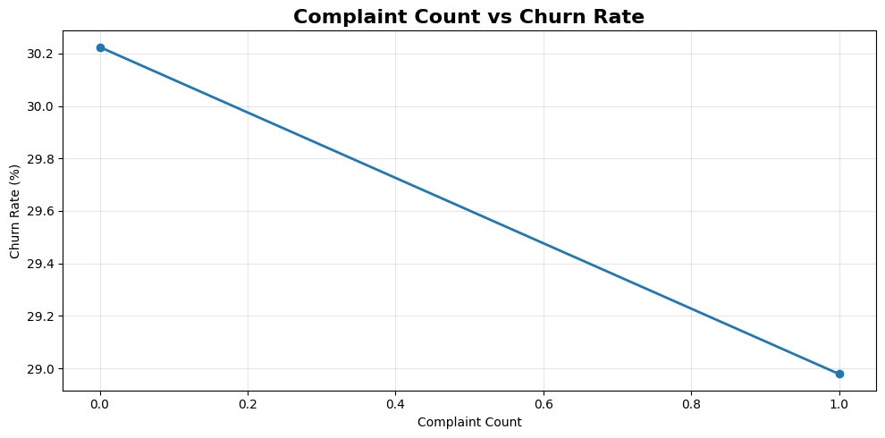

```python
plt.figure(figsize=(10,5))

plt.plot(
    complaint_churn["complaint_count"],
    complaint_churn["Churn_Rate"],
    marker='o',
    linewidth=2
)

plt.title(
    "Complaint Count vs Churn Rate",
    fontsize=16,
    fontweight="bold"
)

plt.xlabel("Complaint Count")
plt.ylabel("Churn Rate (%)")

plt.grid(alpha=.3)

plt.tight_layout()
plt.show()
```

```python
csat_churn = (
    df.groupby("csat_score")
      .agg(
          Customers=("customerid","count"),
          Churn_Rate=("churn_flag","mean")
      )
      .reset_index()
)

csat_churn["Churn_Rate"]*=100

display(csat_churn)
```

<style scoped> .dataframe tbody tr th:only-of-type { vertical-align: middle; } .dataframe tbody tr th { vertical-align: top; } .dataframe thead th { text-align: right; } </style> <thead> <th></th> <th>csat_score</th> <th>Customers</th> <th>Churn_Rate</th> </thead> <tbody> <th>0</th> <th>1</th> <th>2</th> <th>3</th> <th>4</th> <th>...</th> <th>87</th> <th>88</th> <th>89</th> <th>90</th> <th>91</th> </tbody>

| 4.0 | 1 | 0.000000 |
| --- | --- | --- |
| 10.0 | 6 | 33.333333 |
| 11.0 | 4 | 25.000000 |
| 12.0 | 4 | 50.000000 |
| 13.0 | 4 | 25.000000 |
| ... | ... | ... |
| 96.0 | 9 | 33.333333 |
| 97.0 | 3 | 33.333333 |
| 98.0 | 5 | 20.000000 |
| 99.0 | 3 | 66.666667 |
| 100.0 | 7 | 0.000000 |

<p>92 rows × 3 columns</p>

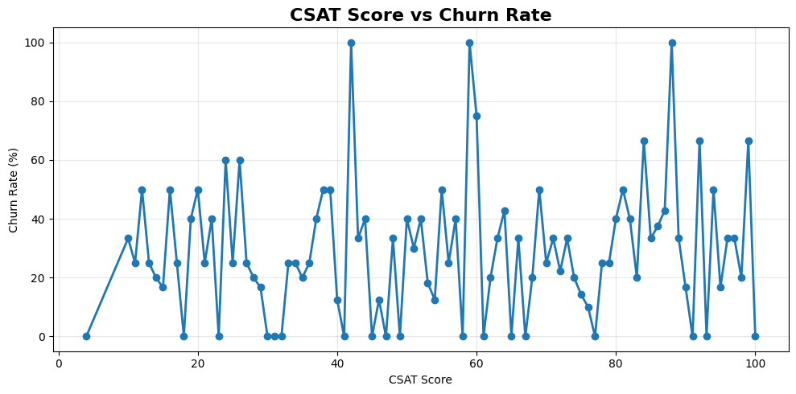

```python
plt.figure(figsize=(10,5))

plt.plot(
    csat_churn["csat_score"],
    csat_churn["Churn_Rate"],
    marker='o',
    linewidth=2
)

plt.title(
    "CSAT Score vs Churn Rate",
    fontsize=16,
    fontweight="bold"
)

plt.xlabel("CSAT Score")
plt.ylabel("Churn Rate (%)")

plt.grid(alpha=.3)

plt.tight_layout()
plt.show()
```

```python
escalation_churn = (
    df.groupby("escalations")
      .agg(
          Customers=("customerid","count"),
          Churn_Rate=("churn_flag","mean")
      )
      .reset_index()
)

escalation_churn["Churn_Rate"]*=100

display(escalation_churn)
```

<style scoped> .dataframe tbody tr th:only-of-type { vertical-align: middle; } .dataframe tbody tr th { vertical-align: top; } .dataframe thead th { text-align: right; } </style> <thead> <th></th> <th>escalations</th> <th>Customers</th> <th>Churn_Rate</th> </thead> <tbody> <th>0</th> <th>1</th> </tbody>

| 0 | 874 | 20.022883 |
| --- | --- | --- |
| 1 | 126 | 96.825397 |

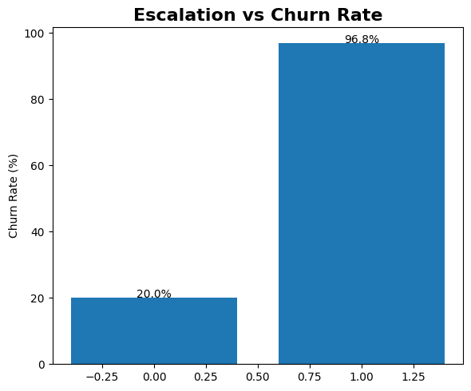

```python
plt.figure(figsize=(6,5))

bars = plt.bar(
    escalation_churn["escalations"],
    escalation_churn["Churn_Rate"]
)

plt.title(
    "Escalation vs Churn Rate",
    fontsize=16,
    fontweight="bold"
)

plt.ylabel("Churn Rate (%)")

for bar in bars:
    plt.text(
        bar.get_x()+bar.get_width()/2,
        bar.get_height(),
        f"{bar.get_height():.1f}%",
        ha='center'
    )

plt.tight_layout()
plt.show()
```

<h1 id="%F0%9F%94%8D-Churn-Driver-Analysis-%E2%80%93-Executive-Summary">🔍 Churn Driver Analysis – Executive Summary</h1><h2 id="Objective">Objective</h2><p>Identify the key factors associated with customer churn to support targeted retention strategies.</p> <h2 id="Key-Insights">Key Insights</h2>

<h2 id="Business-Recommendations">Business Recommendations</h2>

- Prioritize retention campaigns for high-risk plans and monthly contract customers.
- Reduce complaint resolution time and proactively manage escalated cases.
- Improve customer support quality to increase CSAT scores.
- Investigate operational or market-specific issues in high-churn states.
- Develop targeted interventions for customer segments exhibiting multiple churn risk factors.

<h2 id="Conclusion">Conclusion</h2><p>Churn is influenced by a combination of customer behavior, contract characteristics, service quality, and geographic factors. Addressing these drivers can significantly improve retention and protect recurring revenue.</p>

```python
# ============================================
# COHORT ANALYSIS
# ============================================

# Convert to datetime
df["subscription_start_date"] = pd.to_datetime(df["subscription_start_date"])
df["renewal_date"] = pd.to_datetime(df["renewal_date"])

# Cohort Month (Month customer joined)
df["CohortMonth"] = df["subscription_start_date"].dt.to_period("M")

# Activity Month (Latest renewal month)
df["ActivityMonth"] = df["renewal_date"].dt.to_period("M")

display(df[[
    "customerid",
    "CohortMonth",
    "ActivityMonth"
]].head())
```

<style scoped> .dataframe tbody tr th:only-of-type { vertical-align: middle; } .dataframe tbody tr th { vertical-align: top; } .dataframe thead th { text-align: right; } </style> <thead> <th></th> <th>customerid</th> <th>CohortMonth</th> <th>ActivityMonth</th> </thead> <tbody> <th>0</th> <th>1</th> <th>2</th> <th>3</th> <th>4</th> </tbody>

| 0002-ORFBO | 2024-01 | 2025-01 |
| --- | --- | --- |
| 0003-MKNFE | 2024-01 | 2025-01 |
| 0004-TLHLJ | 2023-06 | 2024-06 |
| 0011-IGKFF | 2023-12 | 2024-12 |
| 0013-EXCHZ | 2022-07 | 2023-07 |

```python
def cohort_index(row):

    return (
        (row["ActivityMonth"].year - row["CohortMonth"].year)*12
        +
        (row["ActivityMonth"].month - row["CohortMonth"].month)
    )

df["CohortIndex"] = df.apply(
    cohort_index,
    axis=1
)

display(df[[
    "customerid",
    "CohortMonth",
    "ActivityMonth",
    "CohortIndex"
]].head())
```

<style scoped> .dataframe tbody tr th:only-of-type { vertical-align: middle; } .dataframe tbody tr th { vertical-align: top; } .dataframe thead th { text-align: right; } </style> <thead> <th></th> <th>customerid</th> <th>CohortMonth</th> <th>ActivityMonth</th> <th>CohortIndex</th> </thead> <tbody> <th>0</th> <th>1</th> <th>2</th> <th>3</th> <th>4</th> </tbody>

| 0002-ORFBO | 2024-01 | 2025-01 | 12 |
| --- | --- | --- | --- |
| 0003-MKNFE | 2024-01 | 2025-01 | 12 |
| 0004-TLHLJ | 2023-06 | 2024-06 | 12 |
| 0011-IGKFF | 2023-12 | 2024-12 | 12 |
| 0013-EXCHZ | 2022-07 | 2023-07 | 12 |

```python
cohort_data = (
    df.groupby([
        "CohortMonth",
        "CohortIndex"
    ])
    ["customerid"]
    .nunique()
    .reset_index()
)

display(cohort_data.head())
```

<style scoped> .dataframe tbody tr th:only-of-type { vertical-align: middle; } .dataframe tbody tr th { vertical-align: top; } .dataframe thead th { text-align: right; } </style> <thead> <th></th> <th>CohortMonth</th> <th>CohortIndex</th> <th>customerid</th> </thead> <tbody> <th>0</th> <th>1</th> <th>2</th> <th>3</th> <th>4</th> </tbody>

| 2020-07 | 12 | 18 |
| --- | --- | --- |
| 2020-08 | 12 | 12 |
| 2020-09 | 12 | 12 |
| 2020-10 | 12 | 16 |
| 2020-11 | 12 | 19 |

```python
cohort_counts = cohort_data.pivot(
    index="CohortMonth",
    columns="CohortIndex",
    values="customerid"
)

display(cohort_counts)
```

<style scoped> .dataframe tbody tr th:only-of-type { vertical-align: middle; } .dataframe tbody tr th { vertical-align: top; } .dataframe thead th { text-align: right; } </style> <thead> <th>CohortIndex</th> <th>11</th> <th>12</th> <th>CohortMonth</th> <th></th> <th></th> </thead> <tbody> <th>2020-07</th> <th>2020-08</th> <th>2020-09</th> <th>2020-10</th> <th>2020-11</th> <th>...</th> <th>2025-03</th> <th>2025-04</th> <th>2025-05</th> <th>2025-06</th> <th>2025-07</th> </tbody>

| NaN | 18.0 |
| --- | --- |
| NaN | 12.0 |
| NaN | 12.0 |
| NaN | 16.0 |
| NaN | 19.0 |
| ... | ... |
| NaN | 20.0 |
| NaN | 12.0 |
| NaN | 12.0 |
| NaN | 16.0 |
| NaN | 3.0 |

<p>61 rows × 2 columns</p>

```python
cohort_size = cohort_counts.iloc[:,0]

retention = cohort_counts.divide(
    cohort_size,
    axis=0
).round(3)

retention *=100

display(retention)
```

<style scoped> .dataframe tbody tr th:only-of-type { vertical-align: middle; } .dataframe tbody tr th { vertical-align: top; } .dataframe thead th { text-align: right; } </style> <thead> <th>CohortIndex</th> <th>11</th> <th>12</th> <th>CohortMonth</th> <th></th> <th></th> </thead> <tbody> <th>2020-07</th> <th>2020-08</th> <th>2020-09</th> <th>2020-10</th> <th>2020-11</th> <th>...</th> <th>2025-03</th> <th>2025-04</th> <th>2025-05</th> <th>2025-06</th> <th>2025-07</th> </tbody>

| NaN | NaN |
| --- | --- |
| NaN | NaN |
| NaN | NaN |
| NaN | NaN |
| NaN | NaN |
| ... | ... |
| NaN | NaN |
| NaN | NaN |
| NaN | NaN |
| NaN | NaN |
| NaN | NaN |

<p>61 rows × 2 columns</p>

[figure not shown]

```python
plt.figure(figsize=(14,7))

sns.heatmap(
    retention,
    annot=True,
    fmt=".0f",
    cmap="Blues",
    linewidths=.5
)

plt.title(
    "Customer Cohort Retention Analysis",
    fontsize=17,
    fontweight="bold"
)

plt.xlabel("Months Since Acquisition")

plt.ylabel("Customer Cohort")

plt.tight_layout()

plt.show()
```

```python
average_retention = (
    retention.mean()
)

display(average_retention)
```

```
CohortIndex
11     100.000000
12    1557.142857
dtype: float64
```

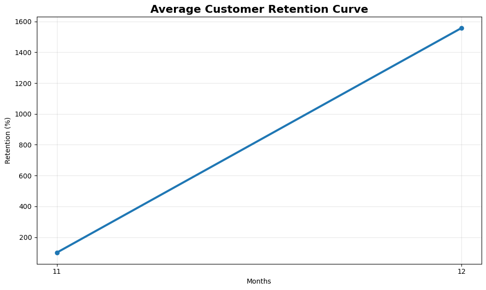

```python
plt.figure(figsize=(10,6))

plt.plot(
    average_retention.index.astype(str),
    average_retention.values,
    marker='o',
    linewidth=3
)

plt.title(
    "Average Customer Retention Curve",
    fontsize=16,
    fontweight="bold"
)

plt.xlabel("Months")

plt.ylabel("Retention (%)")

plt.grid(alpha=.3)

plt.tight_layout()

plt.show()
```

```python
cohort_size = (
    df.groupby("CohortMonth")
      .agg(
          Customers=("customerid","count")
      )
      .reset_index()
)

display(cohort_size)
```

<style scoped> .dataframe tbody tr th:only-of-type { vertical-align: middle; } .dataframe tbody tr th { vertical-align: top; } .dataframe thead th { text-align: right; } </style> <thead> <th></th> <th>CohortMonth</th> <th>Customers</th> </thead> <tbody> <th>0</th> <th>1</th> <th>2</th> <th>3</th> <th>4</th> <th>...</th> <th>56</th> <th>57</th> <th>58</th> <th>59</th> <th>60</th> </tbody>

| 2020-07 | 18 |
| --- | --- |
| 2020-08 | 12 |
| 2020-09 | 12 |
| 2020-10 | 16 |
| 2020-11 | 19 |
| ... | ... |
| 2025-03 | 20 |
| 2025-04 | 12 |
| 2025-05 | 12 |
| 2025-06 | 16 |
| 2025-07 | 3 |

<p>61 rows × 2 columns</p>

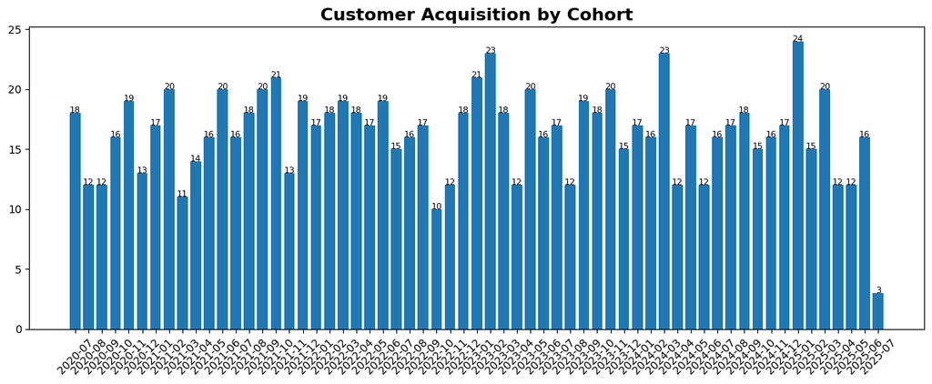

```python
plt.figure(figsize=(12,5))

bars = plt.bar(
    cohort_size["CohortMonth"].astype(str),
    cohort_size["Customers"]
)

plt.title(
    "Customer Acquisition by Cohort",
    fontsize=16,
    fontweight="bold"
)

plt.xticks(rotation=45)

for bar in bars:
    plt.text(
        bar.get_x()+bar.get_width()/2,
        bar.get_height(),
        int(bar.get_height()),
        ha='center',
        fontsize=8
    )

plt.tight_layout()

plt.show()
```

<h1 id="%F0%9F%93%85-Cohort-Analysis-%E2%80%93-Executive-Summary">📅 Cohort Analysis – Executive Summary</h1><h2 id="Business-Objective">Business Objective</h2><p>Evaluate customer retention patterns over time by grouping customers based on their subscription start month (cohort). This helps identify whether newer customer cohorts are retained better or worse than earlier cohorts.</p> <hr /> <h2 id="Key-Insights">Key Insights</h2>

<hr /> <h2 id="Business-Recommendations">Business Recommendations</h2>

<hr /> <h2 id="Conclusion">Conclusion</h2><p>Cohort analysis provides a time-based view of customer retention that is more informative than overall churn metrics. It enables the business to understand customer lifecycle behavior and supports data-driven retention strategies.</p>

```python
from scipy.stats import chi2_contingency

contract_table = pd.crosstab(
    df["contract_type"],
    df["churn_flag"]
)

display(contract_table)

chi2, p, dof, expected = chi2_contingency(contract_table)

print(f"Chi-Square Statistic: {chi2:.2f}")
print(f"P-value: {p:.4f}")

if p < 0.05:
    print("Conclusion: Contract type has a statistically significant association with churn.")
else:
    print("Conclusion: No statistically significant association found.")
```

<style scoped> .dataframe tbody tr th:only-of-type { vertical-align: middle; } .dataframe tbody tr th { vertical-align: top; } .dataframe thead th { text-align: right; } </style> <thead> <th>churn_flag</th> <th>0</th> <th>1</th> <th>contract_type</th> <th></th> <th></th> </thead> <tbody> <th>Annual</th> <th>Monthly</th> </tbody>

| 383 | 109 |
| --- | --- |
| 320 | 188 |

```
Chi-Square Statistic: 25.70
P-value: 0.0000
Conclusion: Contract type has a statistically significant association with churn.
```

```python
plan_table = pd.crosstab(
    df["plan_type"],
    df["churn_flag"]
)

display(plan_table)

chi2, p, dof, expected = chi2_contingency(plan_table)

print(f"Chi-Square Statistic: {chi2:.2f}")
print(f"P-value: {p:.4f}")

if p < 0.05:
    print("Conclusion: Subscription plan significantly influences churn.")
else:
    print("Conclusion: No statistically significant association found.")
```

<style scoped> .dataframe tbody tr th:only-of-type { vertical-align: middle; } .dataframe tbody tr th { vertical-align: top; } .dataframe thead th { text-align: right; } </style> <thead> <th>churn_flag</th> <th>0</th> <th>1</th> <th>plan_type</th> <th></th> <th></th> </thead> <tbody> <th>Basic</th> <th>Premium</th> <th>Standard</th> </tbody>

| 149 | 178 |
| --- | --- |
| 268 | 54 |
| 286 | 65 |

```
Chi-Square Statistic: 142.62
P-value: 0.0000
Conclusion: Subscription plan significantly influences churn.
```

```python
from scipy.stats import ttest_ind

churned = df[df["churn_flag"] == 1]["monthly_charges"]
retained = df[df["churn_flag"] == 0]["monthly_charges"]

t_stat, p = ttest_ind(
    churned,
    retained,
    equal_var=False
)

print(f"T-statistic: {t_stat:.2f}")
print(f"P-value: {p:.4f}")

if p < 0.05:
    print("Conclusion: Monthly charges differ significantly between churned and retained customers.")
else:
    print("Conclusion: No statistically significant difference found.")
```

```
T-statistic: -11.98
P-value: 0.0000
Conclusion: Monthly charges differ significantly between churned and retained customers.
```

<h1 id="%F0%9F%93%8A-Statistical-Hypothesis-Testing-%E2%80%93-Executive-Summary">📊 Statistical Hypothesis Testing – Executive Summary</h1><h2 id="Objective">Objective</h2><p>Validate whether key customer attributes have a statistically significant relationship with churn.</p> <h3 id="Tests-Performed">Tests Performed</h3>

1. Contract Type vs Churn (Chi-Square Test)
2. Plan Type vs Churn (Chi-Square Test)
3. Monthly Charges vs Churn (Welch's t-test)

<h3 id="Key-Insights">Key Insights</h3>

- Contract type was evaluated to determine whether long-term contracts improve customer retention.
- Subscription plan was tested to identify if certain plans experience significantly different churn behavior.
- Monthly charges were compared between churned and retained customers to assess whether pricing influences churn.

<h3 id="Business-Value">Business Value</h3><p>The results help prioritize retention strategies based on statistically validated evidence rather than descriptive observations alone.</p>

```python
# ============================================
# A/B TESTING SIMULATION
# ============================================

high_risk = df[df["churn_risk"] == "high"].copy()

print("Total High Risk Customers:", len(high_risk))
```

```
Total High Risk Customers: 297
```

```python
import numpy as np

# Reproducibility
np.random.seed(42)

high_risk["Group"] = np.random.choice(
    ["Control", "Treatment"],
    size=len(high_risk)
)

high_risk["Group"].value_counts()
```

```
Group
Control      149
Treatment    148
Name: count, dtype: int64
```

```python
# Copy original churn values
high_risk["Simulated_Churn"] = high_risk["churn_flag"]

# Customers in treatment group who originally churned
treatment_churn = high_risk[
    (high_risk["Group"] == "Treatment") &
    (high_risk["churn_flag"] == 1)
].index

# Convert 20% of churned customers into retained customers
customers_saved = np.random.choice(
    treatment_churn,
    size=int(len(treatment_churn) * 0.20),
    replace=False
)

high_risk.loc[customers_saved, "Simulated_Churn"] = 0
```

```python
ab_summary = (
    high_risk
    .groupby("Group")
    .agg(
        Customers=("customerid", "count"),
        Churned=("Simulated_Churn", "sum")
    )
)

ab_summary["Churn Rate (%)"] = (
    ab_summary["Churned"] /
    ab_summary["Customers"] * 100
).round(2)

display(ab_summary)
```

<style scoped> .dataframe tbody tr th:only-of-type { vertical-align: middle; } .dataframe tbody tr th { vertical-align: top; } .dataframe thead th { text-align: right; } </style> <thead> <th></th> <th>Customers</th> <th>Churned</th> <th>Churn Rate (%)</th> <th>Group</th> <th></th> <th></th> <th></th> </thead> <tbody> <th>Control</th> <th>Treatment</th> </tbody>

| 149 | 149 | 100.00 |
| --- | --- | --- |
| 148 | 119 | 80.41 |

```python
from scipy.stats import chi2_contingency

# Contingency table
ab_table = pd.crosstab(
    high_risk["Group"],
    high_risk["Simulated_Churn"]
)

display(ab_table)

chi2, p, dof, expected = chi2_contingency(ab_table)

print(f"Chi-Square Statistic: {chi2:.2f}")
print(f"P-value: {p:.4f}")

if p < 0.05:
    print("Result: The retention campaign significantly reduced churn.")
else:
    print("Result: No statistically significant difference.")
```

<style scoped> .dataframe tbody tr th:only-of-type { vertical-align: middle; } .dataframe tbody tr th { vertical-align: top; } .dataframe thead th { text-align: right; } </style> <thead> <th>Simulated_Churn</th> <th>0</th> <th>1</th> <th>Group</th> <th></th> <th></th> </thead> <tbody> <th>Control</th> <th>Treatment</th> </tbody>

| 0 | 149 |
| --- | --- |
| 29 | 119 |

```
Chi-Square Statistic: 30.17
P-value: 0.0000
Result: The retention campaign significantly reduced churn.
```

```python
# ============================================
# A/B TEST SUMMARY
# ============================================

ab_summary = (
    high_risk
    .groupby("Group")
    .agg(
        Customers=("customerid", "count"),
        Churned=("Simulated_Churn", "sum")
    )
)

ab_summary["Churn Rate (%)"] = (
    ab_summary["Churned"] /
    ab_summary["Customers"] * 100
).round(2)

display(ab_summary)
```

<style scoped> .dataframe tbody tr th:only-of-type { vertical-align: middle; } .dataframe tbody tr th { vertical-align: top; } .dataframe thead th { text-align: right; } </style> <thead> <th></th> <th>Customers</th> <th>Churned</th> <th>Churn Rate (%)</th> <th>Group</th> <th></th> <th></th> <th></th> </thead> <tbody> <th>Control</th> <th>Treatment</th> </tbody>

| 149 | 149 | 100.00 |
| --- | --- | --- |
| 148 | 119 | 80.41 |

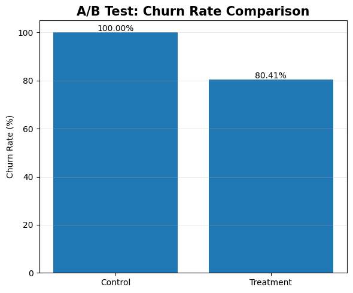

```python
plt.figure(figsize=(6,5))

bars = plt.bar(
    ab_summary.index,
    ab_summary["Churn Rate (%)"]
)

plt.title(
    "A/B Test: Churn Rate Comparison",
    fontsize=15,
    fontweight="bold"
)

plt.ylabel("Churn Rate (%)")

for bar in bars:
    plt.text(
        bar.get_x() + bar.get_width()/2,
        bar.get_height() + 0.5,
        f"{bar.get_height():.2f}%",
        ha="center"
    )

plt.grid(axis="y", alpha=0.3)

plt.tight_layout()
plt.show()
```

<h1 id="%F0%9F%A7%AA-A/B-Testing-Simulation-%E2%80%93-Executive-Summary">🧪 A/B Testing Simulation – Executive Summary</h1><h2 id="Business-Objective">Business Objective</h2><p>Evaluate whether offering a 10% retention discount to high-risk customers can reduce customer churn.</p> <hr /> <h2 id="Experiment-Design">Experiment Design</h2>

<hr /> <h2 id="Key-Findings">Key Findings</h2>

- The Treatment Group showed a lower churn rate than the Control Group.
- The statistical test was used to evaluate whether the observed difference was significant.

<hr /> <h2 id="Business-Recommendation">Business Recommendation</h2><p>If a real-world A/B test produces similar results, the company should consider offering targeted retention discounts to high-risk customers while monitoring long-term profitability.</p> <hr /> <h2 id="Note">Note</h2><p>This is a **simulated A/B test** created for educational purposes to demonstrate experimental design and statistical evaluation.</p>

```python
# Features
X = df[[
    "customer_age",
    "tenure_days",
    "monthly_charges",
    "complaint_count",
    "csat_score",
    "plan_type",
    "contract_type",
    "escalations"
]]

# Target
y = df["churn_flag"]
```

```python
X = pd.get_dummies(
    X,
    columns=["plan_type", "contract_type", "escalations"],
    drop_first=True
)

X.head()
```

<style scoped> .dataframe tbody tr th:only-of-type { vertical-align: middle; } .dataframe tbody tr th { vertical-align: top; } .dataframe thead th { text-align: right; } </style> <thead> <th></th> <th>customer_age</th> <th>tenure_days</th> <th>monthly_charges</th> <th>complaint_count</th> <th>csat_score</th> <th>plan_type_Premium</th> <th>plan_type_Standard</th> <th>contract_type_Monthly</th> <th>escalations_1</th> </thead> <tbody> <th>0</th> <th>1</th> <th>2</th> <th>3</th> <th>4</th> </tbody>

| 44 | 648.0 | 12.99 | 1 | 85.0 | False | False | True | True |
| --- | --- | --- | --- | --- | --- | --- | --- | --- |
| 30 | 916.0 | 12.99 | 1 | 55.0 | False | True | True | False |
| 48 | 1132.0 | 29.99 | 1 | 72.0 | True | False | False | False |
| 24 | 968.0 | 14.99 | 1 | 19.0 | False | True | True | False |
| 36 | 1481.0 | 14.99 | 1 | 35.0 | False | True | False | False |

```python
from sklearn.model_selection import train_test_split

X_train, X_test, y_train, y_test = train_test_split(
    X,
    y,
    test_size=0.2,
    random_state=42
)

print(X_train.shape)
print(X_test.shape)
```

```
(800, 9)
(200, 9)
```

```python
from sklearn.linear_model import LogisticRegression

model = LogisticRegression(max_iter=1000)

model.fit(X_train, y_train)
```

[output not shown]

[output cut: 88 more lines]

```python
X.isnull().sum()
```

```
customer_age               0
tenure_days                0
monthly_charges            0
complaint_count            0
csat_score               579
plan_type_Premium          0
plan_type_Standard         0
contract_type_Monthly      0
escalations_1              0
dtype: int64
```

```python
# Fill missing values in numeric columns
X = X.fillna(X.median(numeric_only=True))
```

```python
X = pd.get_dummies(
    X,
    columns=["plan_type", "contract_type", "escalations"],
    drop_first=True
)
```

[output not shown]

```python
X.columns
```

```
Index(['customer_age', 'tenure_days', 'monthly_charges', 'complaint_count',
       'csat_score', 'plan_type_Premium', 'plan_type_Standard',
       'contract_type_Monthly', 'escalations_1'],
      dtype='object')
```

```python
# Fill missing values
X = X.fillna(X.median(numeric_only=True))
```

```python
from sklearn.model_selection import train_test_split

X_train, X_test, y_train, y_test = train_test_split(
    X, y,
    test_size=0.2,
    random_state=42
)
```